# W10-Dashboards Assignment

NCMA Dashboard and Shiny App

Author

Published

May 16, 2026

# Project 1:

## Project description

- This dashboard is dedicated in analyzing NCMA SGV website traffic and user engagement using GA4 data. This can help understand which channels generate highest session valume and which channels produces strong engagement.

## Data description

Variables that would be includes is

- Sessions
- Users
- Engagement Rate
- Device Category
- Total engagement time

Channels that we will be looking into includes Direct, Organic Search, Referral, and Other.

## R Code.

- You can add the code you had in an unexecutable chunk using the following chunk. Copy the code from the source mode of the qmd file. Make everything, including the YAML header.

```r
---

title: "NCMA SGV Website Dashboard"
author: "Kayla Cortez"

format:
  dashboard:
    theme: cosmo

execute:
  echo: false
  warning: false
  message: false

---
```

### Data

```r
library(tidyverse)
library(ggplot2)
library(arrow)
library(scales)
ncma_data <- open_dataset("ncma_data/parquet/channel_daily_kpis_v1")

channel_data <- ncma_data |>
  collect()

total_sessions <- channel_data |>
  summarise(
    total_sessions = sum(sessions, na.rm = TRUE)
  )

total_sessions
```

```
# A tibble: 1 × 1
  total_sessions
           <int>
1            924
```

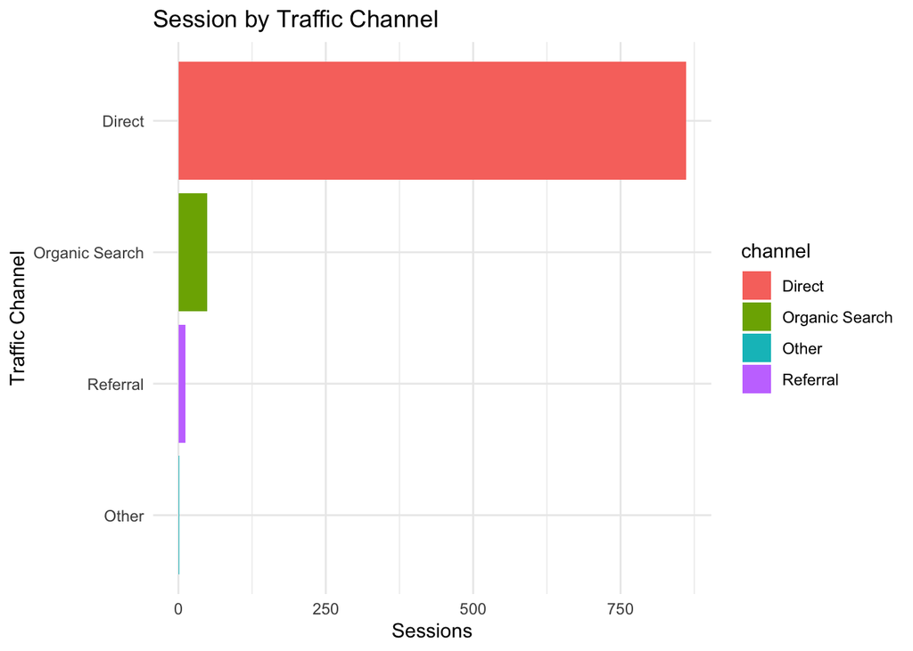

```r
sessions_by_channel <- channel_data |>
  group_by(channel) |>
  summarise(
    sessions = sum(sessions, na.rm = TRUE)
  )

ggplot(sessions_by_channel,
       aes(x = reorder(channel, sessions),
           y = sessions,
           fill = channel)) +
geom_col() +
  coord_flip() +
  theme_minimal() +
  labs(
    title = "Session by Traffic Channel",
    x = "Traffic Channel",
    y = "Sessions"
  ) + scale_y_continuous(labels = comma)
```

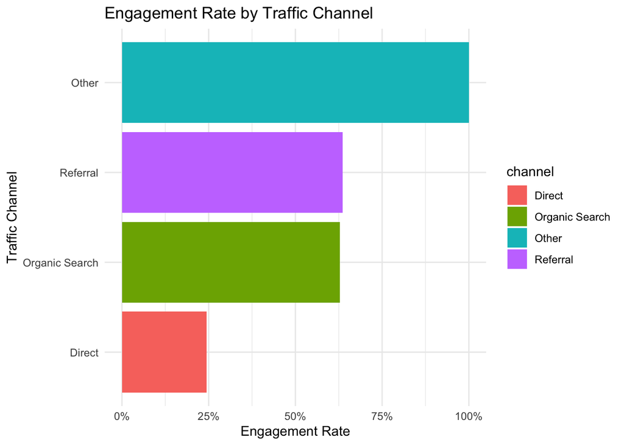

```r
engagement_by_channel <- channel_data |>
  group_by(channel) |>
  summarise(
    engagement_rate = mean(engaged_sessions / sessions, na.rm = TRUE)
  )

ggplot(engagement_by_channel,
       aes(x = reorder(channel, engagement_rate),
           y = engagement_rate,
           fill = channel)) +
  geom_col() +
  coord_flip() +
  theme_minimal() +
  labs(
    title = "Engagement Rate by Traffic Channel",
    x  = "Traffic Channel",
    y = "Engagement Rate"
  ) + scale_y_continuous(labels = percent)
```